```r
options(OutDec = ".")  # Asegurar punto decimal en este chunk

# Función para generar datos aleatorios del problema
generar_datos <- function() {
  # Aleatorización de sabores de tortas (4 sabores diferentes)
  sabores_disponibles <- list(
    c("Nuez", "Almendra", "Chocolate", "Naranja"),
    c("Vainilla", "Fresa", "Limón", "Coco"),
    c("Manzana", "Durazno", "Mora", "Maracuyá"),
    c("Café", "Caramelo", "Miel", "Canela"),
    c("Piña", "Banano", "Uva", "Cereza")
  )
  sabores <- sample(sabores_disponibles, 1)[[1]]

  # Generar números de clientes que prefieren cada sabor (rango realista)
  preferencias <- sample(120:200, 4, replace = TRUE)
  names(preferencias) <- sabores

  # Ordenar para identificar los 2 más preferidos
  preferencias_ordenadas <- sort(preferencias, decreasing = TRUE)
  sabores_mas_preferidos <- names(preferencias_ordenadas)[1:2]

  # Aleatorización de días de la semana y ventas
  dias_semana <- c("Lunes", "Martes", "Miércoles", "Jueves", "Viernes", "Sábado", "Domingo")
  ventas_por_dia <- sample(20:50, 7, replace = TRUE)
  names(ventas_por_dia) <- dias_semana

  # Identificar el día con mayor número de ventas
  dia_mayor_ventas <- names(which.max(ventas_por_dia))

  # ===== ESTRATEGIA AVANZADA DE GENERACIÓN DE OPCIONES =====

  # 1. POOL DE OPCIONES CORRECTAS (3 formulaciones diferentes)
  pool_correctas <- c(
    paste0("Se venderán el ", tolower(dia_mayor_ventas),
           " y los sabores serán ", tolower(sabores_mas_preferidos[1]),
           " y ", tolower(sabores_mas_preferidos[2]), "."),
    paste0("La promoción será el ", tolower(dia_mayor_ventas),
           " con tortas de ", tolower(sabores_mas_preferidos[1]),
           " y ", tolower(sabores_mas_preferidos[2]), "."),
    paste0("El día ", tolower(dia_mayor_ventas),
           " se ofrecerán sabores ", tolower(sabores_mas_preferidos[1]),
           " y ", tolower(sabores_mas_preferidos[2]), ".")
  )

  # Seleccionar aleatoriamente 1 opción correcta del pool
  respuesta_correcta <- sample(pool_correctas, 1)

  # 2. POOL DE DISTRACTORES PEDAGÓGICOS (6 distractores específicos)
  otros_dias <- dias_semana[dias_semana != dia_mayor_ventas]
  otros_sabores <- sabores[!sabores %in% sabores_mas_preferidos]

  # Distractores tipo 1: Día correcto, sabores incorrectos (2 opciones)
  distractores_tipo1 <- c(
    paste0("Se venderán el ", tolower(dia_mayor_ventas),
           " y los sabores serán ", tolower(otros_sabores[1]),
           " y ", tolower(otros_sabores[2]), "."),
    paste0("La promoción será el ", tolower(dia_mayor_ventas),
           " con tortas de ", tolower(otros_sabores[2]),
           " y ", tolower(sabores_mas_preferidos[2]), ".")
  )

  # Distractores tipo 2: Sabores correctos, día incorrecto (2 opciones)
  dias_distractores <- sample(otros_dias, 2)
  distractores_tipo2 <- c(
    paste0("Se venderán el ", tolower(dias_distractores[1]),
           " y los sabores serán ", tolower(sabores_mas_preferidos[1]),
           " y ", tolower(sabores_mas_preferidos[2]), "."),
    paste0("El día ", tolower(dias_distractores[2]),
           " se ofrecerán sabores ", tolower(sabores_mas_preferidos[1]),
           " y ", tolower(sabores_mas_preferidos[2]), ".")
  )

  # Distractores tipo 3: Ambos elementos incorrectos pero plausibles (2 opciones)
  dias_distractores_extra <- sample(otros_dias[!otros_dias %in% dias_distractores], 2)
  distractores_tipo3 <- c(
    paste0("Se venderán el ", tolower(dias_distractores_extra[1]),
           " y los sabores serán ", tolower(otros_sabores[1]),
           " y ", tolower(sabores_mas_preferidos[1]), "."),
    paste0("La promoción será el ", tolower(dias_distractores_extra[2]),
           " con tortas de ", tolower(otros_sabores[2]),
           " y ", tolower(otros_sabores[1]), ".")
  )

  # Pool completo de distractores
  pool_distractores <- c(distractores_tipo1, distractores_tipo2, distractores_tipo3)

  # 3. VALIDACIÓN DE UNICIDAD Y SELECCIÓN
  # Función para calcular similitud textual
  calcular_similitud <- function(texto1, texto2) {
    palabras1 <- strsplit(tolower(texto1), "\\W+")[[1]]
    palabras2 <- strsplit(tolower(texto2), "\\W+")[[1]]
    interseccion <- length(intersect(palabras1, palabras2))
    union <- length(union(palabras1, palabras2))
    return(interseccion / union)
  }

  # Seleccionar 3 distractores únicos
  distractores_seleccionados <- c()
  tipos_seleccionados <- c()  # Para trazabilidad
  intentos <- 0
  max_intentos <- 50  # Reducido para eficiencia

  while(length(distractores_seleccionados) < 3 && intentos < max_intentos) {
    intentos <- intentos + 1

    # Seleccionar un distractor aleatorio
    candidato_idx <- sample(1:length(pool_distractores), 1)
    candidato <- pool_distractores[candidato_idx]

    # Determinar tipo de distractor para trazabilidad
    if(candidato_idx <= 2) {
      tipo_candidato <- "dia_correcto_sabores_incorrectos"
    } else if(candidato_idx <= 4) {
      tipo_candidato <- "sabores_correctos_dia_incorrecto"
    } else {
      tipo_candidato <- "ambos_incorrectos_plausibles"
    }

    # Verificar unicidad con respuesta correcta
    similitud_correcta <- calcular_similitud(candidato, respuesta_correcta)

    # Verificar unicidad con distractores ya seleccionados
    es_unico <- TRUE
    if(length(distractores_seleccionados) > 0) {
      for(distractor_existente in distractores_seleccionados) {
        similitud_distractor <- calcular_similitud(candidato, distractor_existente)
        if(similitud_distractor > 0.4) {  # Umbral más realista del 60% de diferencia
          es_unico <- FALSE
          break
        }
      }
    }

    # Agregar si es único y suficientemente diferente
    if(es_unico && similitud_correcta < 0.4) {
      distractores_seleccionados <- c(distractores_seleccionados, candidato)
      tipos_seleccionados <- c(tipos_seleccionados, tipo_candidato)

      # Remover del pool para evitar reselección
      pool_distractores <- pool_distractores[-candidato_idx]
    }
  }

  # Si no se pudieron generar 3 distractores únicos, usar los primeros 3 del pool
  if(length(distractores_seleccionados) < 3) {
    distractores_seleccionados <- pool_distractores[1:3]
    tipos_seleccionados <- c("dia_correcto_sabores_incorrectos",
                           "sabores_correctos_dia_incorrecto",
                           "ambos_incorrectos_plausibles")
  }

  # 4. ALEATORIZACIÓN Y POSICIONAMIENTO
  todas_opciones <- c(respuesta_correcta, distractores_seleccionados)
  orden_opciones <- sample(1:4)
  opciones_mezcladas <- todas_opciones[orden_opciones]
  posicion_correcta <- which(orden_opciones == 1)

  # 5. DOCUMENTACIÓN Y TRAZABILIDAD
  # Crear mapeo de tipos de distractores para cada posición
  tipos_opciones <- c("respuesta_correcta", tipos_seleccionados)
  tipos_mezclados <- tipos_opciones[orden_opciones]

  return(list(
    sabores = sabores,
    preferencias = preferencias,
    sabores_mas_preferidos = sabores_mas_preferidos,
    dias_semana = dias_semana,
    ventas_por_dia = ventas_por_dia,
    dia_mayor_ventas = dia_mayor_ventas,
    opciones = opciones_mezcladas,
    respuesta_correcta = respuesta_correcta,
    posicion_correcta = posicion_correcta,
    # Información de trazabilidad para debugging y análisis pedagógico
    tipos_opciones = tipos_mezclados,
    pool_correcta_usada = which(pool_correctas == respuesta_correcta),
    distractores_tipos = tipos_seleccionados,
    validacion_unicidad = list(
      intentos_realizados = intentos,
      distractores_generados = length(distractores_seleccionados)
    )
  ))
}

# Generar datos para este ejercicio
datos <- generar_datos()
```

```r
# Crear tabla de preferencias usando TikZ
tabla_preferencias <- paste0("
\\begin{tikzpicture}
\\node[inner sep=0pt] {
  \\begin{tabular}{|c|c|}
    \\hline
    \\textbf{Sabor} & \\textbf{Número de clientes que} \\\\
    & \\textbf{prefieren el sabor} \\\\
    \\hline
    ", datos$sabores[1], " & ", datos$preferencias[datos$sabores[1]], " clientes \\\\
    \\hline
    ", datos$sabores[2], " & ", datos$preferencias[datos$sabores[2]], " clientes \\\\
    \\hline
    ", datos$sabores[3], " & ", datos$preferencias[datos$sabores[3]], " clientes \\\\
    \\hline
    ", datos$sabores[4], " & ", datos$preferencias[datos$sabores[4]], " clientes \\\\
    \\hline
  \\end{tabular}
};
\\end{tikzpicture}
")

# Crear gráfico de barras usando TikZ
max_ventas <- max(datos$ventas_por_dia)
escala_y <- 50 / max_ventas  # Escalar para que la barra más alta sea 50 unidades

grafico_barras <- paste0("
\\begin{tikzpicture}[scale=0.8]
  \\draw[->] (0,0) -- (8,0) node[right] {Día};
  \\draw[->] (0,0) -- (0,6) node[above] {Tortas vendidas};

  % Etiquetas del eje Y
  \\foreach \\y in {0,10,20,30,40,50}
    \\draw (-0.1,\\y/10) -- (0.1,\\y/10) node[left] {\\y};

  % Barras y etiquetas
  \\draw[fill=lightgray] (0.5,0) rectangle (1,", datos$ventas_por_dia[1] * escala_y / 10, ") node[above] {", datos$ventas_por_dia[1], "};
  \\draw[fill=lightgray] (1.5,0) rectangle (2,", datos$ventas_por_dia[2] * escala_y / 10, ") node[above] {", datos$ventas_por_dia[2], "};
  \\draw[fill=lightgray] (2.5,0) rectangle (3,", datos$ventas_por_dia[3] * escala_y / 10, ") node[above] {", datos$ventas_por_dia[3], "};
  \\draw[fill=lightgray] (3.5,0) rectangle (4,", datos$ventas_por_dia[4] * escala_y / 10, ") node[above] {", datos$ventas_por_dia[4], "};
  \\draw[fill=lightgray] (4.5,0) rectangle (5,", datos$ventas_por_dia[5] * escala_y / 10, ") node[above] {", datos$ventas_por_dia[5], "};
  \\draw[fill=lightgray] (5.5,0) rectangle (6,", datos$ventas_por_dia[6] * escala_y / 10, ") node[above] {", datos$ventas_por_dia[6], "};
  \\draw[fill=lightgray] (6.5,0) rectangle (7,", datos$ventas_por_dia[7] * escala_y / 10, ") node[above] {", datos$ventas_por_dia[7], "};

  % Etiquetas del eje X
  \\node[below] at (0.75,-0.3) {Lun};
  \\node[below] at (1.75,-0.3) {Mar};
  \\node[below] at (2.75,-0.3) {Mié};
  \\node[below] at (3.75,-0.3) {Jue};
  \\node[below] at (4.75,-0.3) {Vie};
  \\node[below] at (5.75,-0.3) {Sáb};
  \\node[below] at (6.75,-0.3) {Dom};
\\end{tikzpicture}
")
```

# Question

Una pastelería realizó una encuesta para conocer los sabores de tortas preferidos por sus clientes. La tabla muestra los resultados de la encuesta.

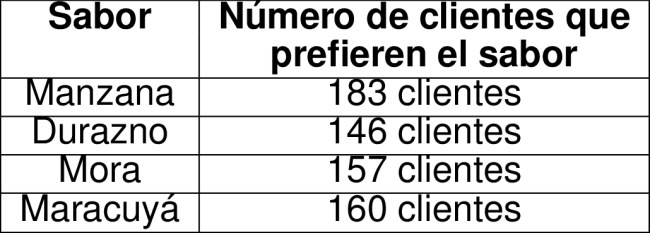

Además, el gerente elaboró una gráfica que muestra el número de tortas vendidas cada día de la última semana.

**Tortas vendidas durante la última semana**

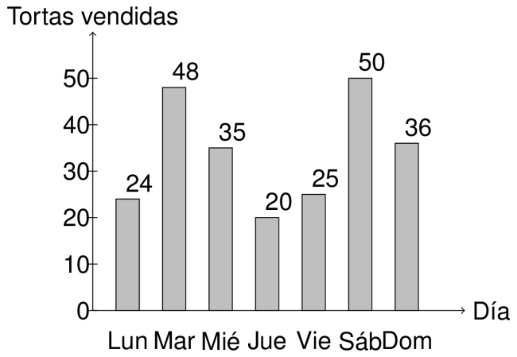

La pastelería planea realizar una promoción con tortas de los 2 sabores preferidos por los clientes, para venderlas el día de la semana con el mayor número de ventas. ¿Cuál día de la semana se venderán las tortas y de qué sabores serán?

## Answerlist

- La promoción será el sábado con tortas de mora y maracuyá.
- Se venderán el domingo y los sabores serán manzana y maracuyá.
- Se venderán el sábado y los sabores serán durazno y mora.
- La promoción será el sábado con tortas de manzana y maracuyá.

# Solution

Para resolver este problema, necesitamos:

1. **Identificar los 2 sabores más preferidos** según la tabla de encuesta
2. **Identificar el día con mayor número de ventas** según el gráfico de barras

**Análisis de la tabla de preferencias:**

- Manzana : 183 clientes
- Maracuyá : 160 clientes
- Mora : 157 clientes
- Durazno : 146 clientes

Los 2 sabores más preferidos son: **Manzana** y **Maracuyá**.

**Análisis del gráfico de ventas:**

El día con mayor número de ventas es: ** Sábado ** con 50 tortas vendidas.

## Answerlist

# Meta-information

exname: pasteleria_sabores_ventas_estadistica extype: schoice exsolution: 0001 exshuffle: TRUE exsection: Estadística/Interpretación de datos/Gráficos y tablas